# Tashu_analysis_R

201202287 제갈수민

2017년 3월 20일

# 데이터 읽어오기

### 작업공간 설정 및 라이브러리

현재의 작업공간을 확인하여 설정하는 작업을 진행한다. 원하는 경로를 setwd를 통해 저장한다.

```r
setwd("/Users/jegalsumin/Documents/Data Science/Class_Data-Science/week03")
```

필요한 라이브러리를 install.pabkages()를 통해 설치한 뒤, library()를 통해 import 시킨다.

```r
library(data.table)
library(ggplot2)
library(plyr)
library(ggmap)
```

### 데이터 읽어오기

지난 주에 가공했던 데이터를 읽어와서 각각의 데이터프레임에 저장 후 몇개를 출력해 확인한다.

```r
tashu_csv <- read.csv("tashu.csv")
station_csv <- read.csv("station.csv")
```

```r
tashu_csv[1:10,]
```

```
##    RENT_STATION   RENT_DATE RETURN_STATION RETURN_DATE
## 1            43 2.01301e+13             34 2.01301e+13
## 2            97 2.01301e+13             NA 2.01301e+13
## 3             2 2.01301e+13             10 2.01301e+13
## 4           106 2.01301e+13            105 2.01301e+13
## 5             4 2.01301e+13              4 2.01301e+13
## 6            21 2.01301e+13            105 2.01301e+13
## 7            90 2.01301e+13             91 2.01301e+13
## 8            13 2.01301e+13             30 2.01301e+13
## 9             1 2.01301e+13              1 2.01301e+13
## 10            1 2.01301e+13              2 2.01301e+13
```

```r
station_csv[1:10,]
```

```
##    번호 키오스크번호   구별                            명칭
## 1     1            1 유성구   무역전시관입구(택시승강장 앞)
## 2     2            2 유성구              대전컨벤션 센터 앞
## 3     3            3   서구            한밭수목원(정문입구)
## 4     4            4   서구 초원아파트104동부근(버스정류장)
## 5     5            5   서구     둔산대공원 입구(버스정류장)
## 6     6            6   서구              백합4가 앞(농협앞)
## 7     7            7   서구         정부청사 입구(대덕대로)
## 8     8            8   서구           정부청사 입구(샘머리)
## 9     9            9   서구       황실아파트앞(성룡초교 앞)
## 10   10           10   서구    만년동 KBS 부근(기업은행 앞)
##                                              위치                 주소
## 1                               엑스포다리 맞은편    유성구 도룡동 3-8
## 2                                 둔산대교 맞은편   유성구 도룡동 4-19
## 3                                   한밭수목원 내      서구 만년동 396
```

[output cut: 18 more lines]

# 데이터 가공 및 분석

## Assignment01. 인기 정류장 TOP10 막대그래프

### 데이터 가공

tashu_csv 데이터 프레임에 있는 ’RENT_STATION’와 ’RETURN_STATION’의 값을 count하여 서로 다른 데이터 프레임에 넣는다. 10개만 출력해보면 다음과 같다.

```r
rent_count <- count(tashu_csv, c('RENT_STATION'))
return_count <- count(tashu_csv, c('RETURN_STATION'))

rent_count[1:10,]
```

```
##    RENT_STATION   freq
## 1             1  49886
## 2             2  25670
## 3             3 174801
## 4             4  40404
## 5             5  34530
## 6             6  26017
## 7             7  30616
## 8             8  52471
## 9             9  21205
## 10           10  38894
```

```r
return_count[1:10,]
```

```
##    RETURN_STATION   freq
## 1               1  49773
## 2               2  25431
## 3               3 174748
## 4               4  40165
## 5               5  34361
## 6               6  26062
## 7               7  30643
## 8               8  52313
## 9               9  21171
## 10             10  38859
```

빌린 지점의 횟수와 반납 지점의 횟수를 가진 각각의 데이터 프레임의 column명을 동일한 이름으로 바꿔주고 그것을 통해 두 데이터 프레임을 merge()함수를 이용해서 outer join한다.

```r
names(rent_count)[names(rent_count) == "RENT_STATION"] <- c("station")
names(return_count)[names(return_count) == "RETURN_STATION"] <- c("station")

total_count <- merge(rent_count, return_count, all=TRUE)
total_count[1:10,]
```

```
##    station   freq
## 1        1  49773
## 2        1  49886
## 3        2  25431
## 4        2  25670
## 5        3 174748
## 6        3 174801
## 7        4  40165
## 8        4  40404
## 9        5  34361
## 10       5  34530
```

total_count을 출력하면 동일한 station값이 겹치는 것을 확인할 수 있는데 이를 다시 합치기 위해, aggregate()함수를 사용한다. total_count데이터 프레임에서 station에 따라서 freq를 합치겠다는 뜻이다.

```r
total_count <- aggregate(freq~station,total_count,sum)
```

각 station별로 횟수를 출력하면 다음과 같다.

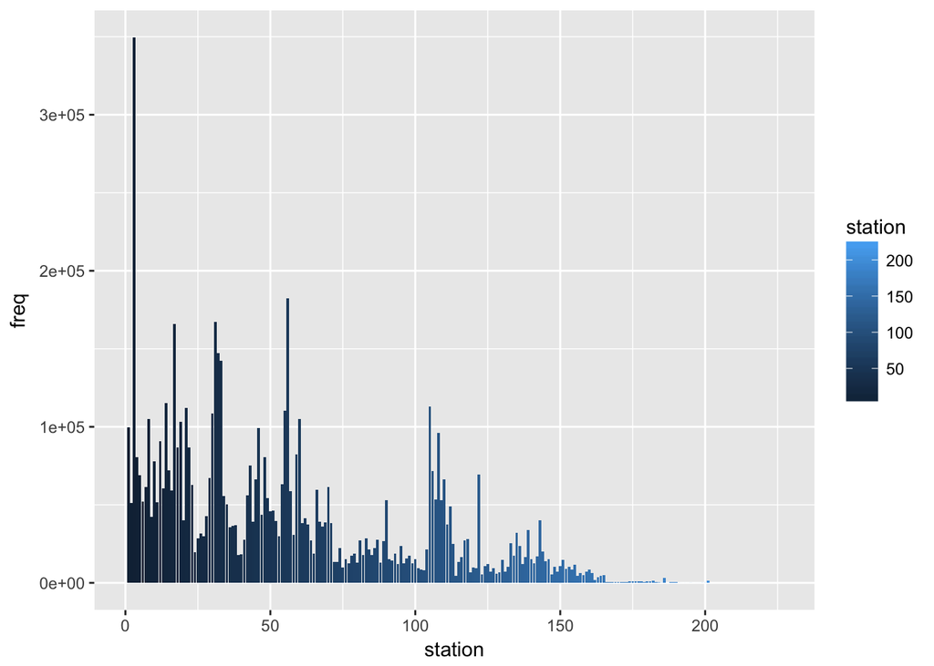

```r
ggplot(data=total_count, aes(x=station, y=freq, fill=station)) +
  geom_bar(stat="identity")
```

다시 여기서 total_count데이터 프레임을 freq에 따라 내림차순 정렬하여 그 중 10개만 top10에 넣어준다.

```r
top10 <- (arrange(total_count,desc(freq)))[1:10,]
top10
```

```
##    station   freq
## 1        3 349549
## 2       56 182347
## 3       31 167060
## 4       17 166055
## 5       32 147279
## 6       33 142510
## 7       14 115049
## 8      105 113046
## 9       21 111935
## 10      55 110199
```

여기서 top10의 station값은 int값이기 때문에 바로 그래프를 출력하면 continuous한 축에 드문 드문 해당 station에 bar chart가 올라간다. 따라서, 이를 discrete한 값으로 바꿔주어야 한다.

```r
top10$station<-as.factor(top10$station)
```

### 데이터 분석

ggplot과 geom_bar를 이용해서 bar chart를 그려준다. x, y축에 각각의 값을 넣어주고 fill=station 옵션을 통해 색을 채워준다. geom_text를 이용해서 각각의 bar에 정확한 freq의 값을 넣어준다. 또한 scale_y_continuous(labels)를 이용해서 y축의 label값을 comma를 이용한 scale 값으로 정해준다.

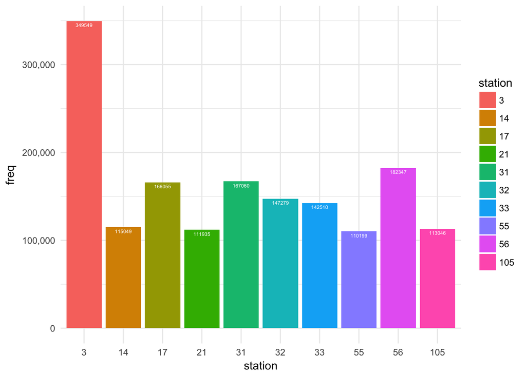

```r
bar_top10 <- ggplot(data=top10, aes(x=station, y=freq, fill=station)) +
  geom_bar(stat="identity") +
  theme_minimal() +
  geom_text(aes(label=freq), vjust=1.6, color="white",position = position_dodge(0.9), size=1.7) +
  scale_y_continuous(labels = scales::comma)
bar_top10
```

## Assignment02. 사용빈도를 보기 위한 지도

### 데이터 가공

각각의 station마다 빈도수를 가지고 있는 데이터 프레임 total_count의 ‘station’ column명을 바꿔서 station정보가 들어있는 station_csv데이터 프레임과 merge한다.

```r
names(total_count)[names(total_count) == "station"] <- c("키오스크번호")
total_station <- merge(x = total_count, y = station_csv, by = '키오스크번호')
names(total_count)[names(total_count) == "키오스크번호"] <- c("station")
total_station[1:10,]
```

```
##    키오스크번호   freq 번호   구별                            명칭
## 1             1  99659    1 유성구   무역전시관입구(택시승강장 앞)
## 2             2  51101    2 유성구              대전컨벤션 센터 앞
## 3             3 349549    3   서구            한밭수목원(정문입구)
## 4             4  80569    4   서구 초원아파트104동부근(버스정류장)
## 5             5  68891    5   서구     둔산대공원 입구(버스정류장)
## 6             6  52079    6   서구              백합4가 앞(농협앞)
## 7             7  61259    7   서구         정부청사 입구(대덕대로)
## 8             8 104784    8   서구           정부청사 입구(샘머리)
## 9             9  42376    9   서구       황실아파트앞(성룡초교 앞)
## 10           10  77753   10   서구    만년동 KBS 부근(기업은행 앞)
##                                              위치                 주소
## 1                               엑스포다리 맞은편    유성구 도룡동 3-8
## 2                                 둔산대교 맞은편   유성구 도룡동 4-19
## 3                                   한밭수목원 내      서구 만년동 396
```

[output cut: 18 more lines]

이때, total_station의 좌표에 위도와 경도는 하나의 string값으로 묶여 있어서 사용이 힘들다. 때문에 이를 strslpit함수를 사용하여 ’,’를 기준으로 위도와 경도로 나누고, 데이터 프레임을 생성하여 lat과 lon의 column에 각각 값을 넣어준다. 그리고 그 데이터프레임을 다시 total_station에 합쳐준다.

```r
coordinates <- data.frame(do.call('rbind', strsplit(as.character(total_station$좌표), split = ',',fixed = TRUE)))
coordinates <- rename(coordinates, c(X1 = "lat", X2 = "lon"))
total_station <- cbind(total_station,coordinates)
total_station[1:10,]
```

```
##    키오스크번호   freq 번호   구별                            명칭
## 1             1  99659    1 유성구   무역전시관입구(택시승강장 앞)
## 2             2  51101    2 유성구              대전컨벤션 센터 앞
## 3             3 349549    3   서구            한밭수목원(정문입구)
## 4             4  80569    4   서구 초원아파트104동부근(버스정류장)
## 5             5  68891    5   서구     둔산대공원 입구(버스정류장)
## 6             6  52079    6   서구              백합4가 앞(농협앞)
## 7             7  61259    7   서구         정부청사 입구(대덕대로)
## 8             8 104784    8   서구           정부청사 입구(샘머리)
## 9             9  42376    9   서구       황실아파트앞(성룡초교 앞)
## 10           10  77753   10   서구    만년동 KBS 부근(기업은행 앞)
##                                              위치                 주소
## 1                               엑스포다리 맞은편    유성구 도룡동 3-8
## 2                                 둔산대교 맞은편   유성구 도룡동 4-19
## 3                                   한밭수목원 내      서구 만년동 396
```

[output cut: 18 more lines]

### 데이터 분석

대전 지역의 지도를 띄워주기 위해 geocode를 통해 대전의 위도와 경도를 받아온다.

```r
daejon_gc <-  geocode('Daejon')
daejon_cent <- as.numeric(daejon_gc)
```

ggmap을 통해서 받아온 대전의 위도와 경도를 중심으로 일정한 줌 안의 지도를 띄워준다. geom_point를 통해서 total_station의 lon과 lat의 값으로 지도위에 점을 찍어준다. 이때, total_station의 lon,lat값은 string형태이기 때문에 이를 다시 숫자 형태로 바꿔서 넣어주고, size는 빈도수와 비례해서 지정해준다.

[figure not shown]

```r
dm <-
  ggmap(get_googlemap(center=daejon_cent, scale = 1, maptype = "roadmap", zoom=13)) +
  geom_point(aes(x = as.numeric(as.character(lon)), y = as.numeric(as.character(lat))), colour = "purple", alpha = .5, size = total_station$freq*0.000025, data = total_station)
dm
```

## Assignment03. 인기 Top20 경로 그래프

### 데이터 가공

경로에 대한 데이터를 가져오기 위해 tashu_csv에서 na값이 없는 row만 추출해서 trace 데이터 프레임에 넣어준다. ’RENT_STATION’과 ’RETURN_STATION’의 값을 기준으로 갯수를 세어 그 값을 trace에 넣는다. 이를 freq를 기준으로 내림차순 정렬하여 20개를 뽑아낸다.

```r
trace <- na.omit(tashu_csv)
trace <- count(trace, c('RENT_STATION','RETURN_STATION'))
trace <- (arrange(trace,desc(freq)))[1:20,]
trace
```

```
##    RENT_STATION RETURN_STATION  freq
## 1             3              3 84496
## 2            31             31 21749
## 3            56             56 18343
## 4            21            105 17220
## 5             1              1 14489
## 6            32             32 12177
## 7           105             21 12154
## 8            33             33 11973
## 9            17             17 11966
## 10           56             32 11868
## 11           32             56 11118
## 12           55             55 11111
## 13            5              5 10798
## 14          108            108  9926
## 15           90             90  9650
## 16            8              8  9560
## 17           14             14  9231
## 18           21             21  9006
## 19           18             18  8192
## 20          105             22  8074
```

이때, station은 int값이므로 trace에 해당 점을 찍게 되면 continuous하게 그래프가 그려진다. 점이 있는 지점마다 그래프를 그리고 싶으므로, as.factor()를 통해 discrete 하게 바꿔준다.

```r
trace_discrete <- trace
trace_discrete$RENT_STATION <- as.factor(trace$RENT_STATION)
trace_discrete$RETURN_STATION <- as.factor(trace$RETURN_STATION)
```

column의 이름을 바꿔준다.

```r
names(trace_discrete)[names(trace_discrete) == "RENT_STATION"] <- c("Rent_Station")
names(trace_discrete)[names(trace_discrete) == "RETURN_STATION"] <- c("Return_Station")
names(trace_discrete)[names(trace_discrete) == "freq"] <- c("Frequency")
```

### 데이터 분석

ggplot을 통해 TOP20의 경로를 점그래프로 그려준다.

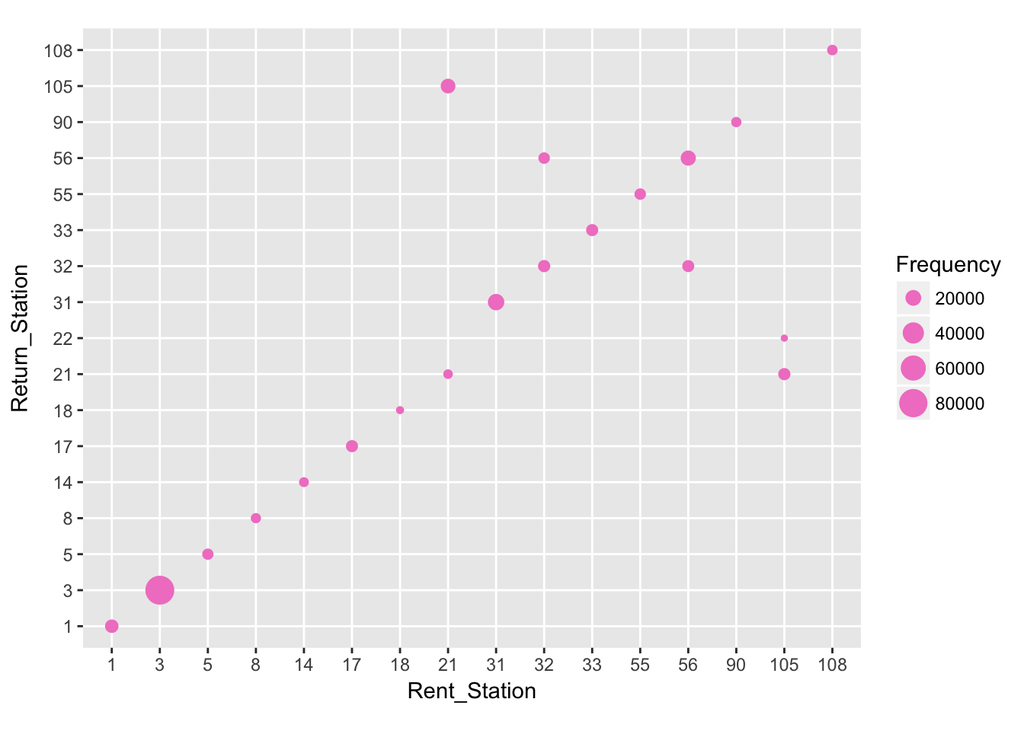

```r
point_trace_discrete <- ggplot(data=trace_discrete, aes(x=Rent_Station, y=Return_Station, size = Frequency)) +
  geom_point(colour='#F183CA') +
  coord_fixed(ratio = 3/4)
point_trace_discrete
```

discrete하게 만들지 않은 데이터 프레임을 그래프로 그리면 다음과같이 나타난다.

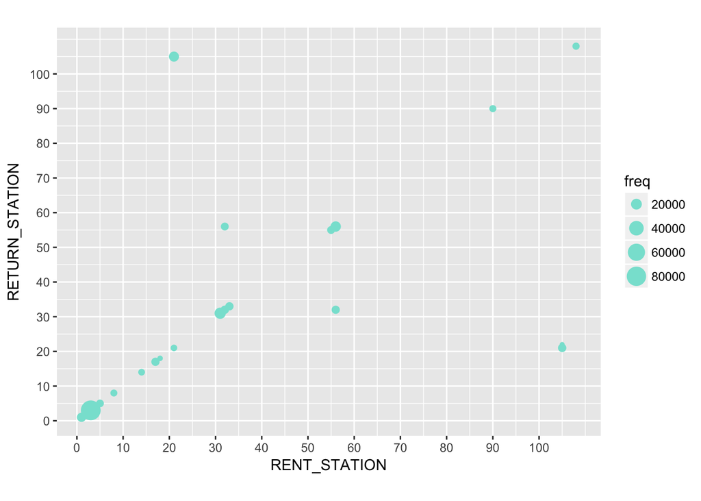

```r
point_trace <- ggplot(data=trace, aes(x=RENT_STATION, y=RETURN_STATION, size = freq)) +
  geom_point(colour="#86E2D5") +
  scale_x_continuous(breaks=seq(0, max(trace$RENT_STATION), 10)) +
  scale_y_continuous(breaks=seq(0, max(trace$RETURN_STATION), 10)) +
  coord_fixed(ratio = 3/4)
point_trace
```